# Has the danish funerary practize secularized?

Emma-Marie Vitskov Jørgensen

2022-11-07, updated 09 January, 2023

## Introduction

Some scholars claim that Denmark are one of the most secularized countries in the world (Walter 2015,5). For my final project I will investigate if this secularization has affected the way Danes likes to be buried. Has the danish funerary practice been secularized, or does the development in funeral types tell a different story?

My research question:How can the development in the number of civil funerals in Denmark from 2006-2021 be characterized?

To answer my research question I will be analyzing a data sets from Danmarks Statistik. When I downloaded the data set from the website, it was downloaded as an excel file, and I converted it into a csv format before loading them into this script. The data sets can be found in the “data” folder on my Github account, and information about the data sets from this rmarkdown script can be found under “Required Metadata” in the project report.

Link to Github: https://github.com/Emma-Marie/final_project

References: Walter, Tony (2015), ”Secularization”, In: C.M. Parkes & W. Young, eds Death and Bereavement Across Cultures, London: Routledge, 2nd edn, 2015, pp. 133-148.

### Loading packages

Loading the packages needed for my data processing and analysis-

```r
library(tidyverse)
```

```r
library(dplyr)
library(ggplot2)
```

### Loading messy data set

Now I’m able to load the raw and messy data from Danmarks Statistik into this script using the `read_csv()` function:

```r
setwd('..')
funerals_messy <- read_csv("./data/funarals_messy.csv")
#checking the data type
class(funerals_messy) #it's a tibble
```

```
## [1] "spec_tbl_df" "tbl_df"      "tbl"         "data.frame"
```

## Inspect the `funerals_messy` data

I will inspect all the data sets to check if it is clean and ready for analysis:

```r
#inspecting the data
head(funerals_messy)
```

```
## # A tibble: 6 × 1
##   `Kirkelige handlinger efter bevægelse og tid;;;;;;;;;;;;;;;;`
##   <chr>
## 1 Enhed: Antal;;;;;;;;;;;;;;;;
## 2 ;2006;2007;2008;2009;2010;2011;2012;2013;2014;2015;2016;2017;2018;2019;2020;2…
## 3 Dødsfald registreret;53224;55990;54914;55121;54579;52774;52529;52110;50938;52…
## 4 Begravet/bisat under medvirken af pastoratets præster fra sognets kirke;27253…
## 5 Begravet/bisat under medvirken af pastoratets præster andetsteds end fra sogn…
## 6 Begravet/bisat under medvirken af andre præster i folkekirken fra sognets kir…
```

```r
tail(funerals_messy)
```

```
## # A tibble: 6 × 1
##   `Kirkelige handlinger efter bevægelse og tid;;;;;;;;;;;;;;;;`
##   <chr>
## 1 Begravet/bisat under medvirken af andre præster i folkekirken fra sognets kir…
## 2 Begravet/bisat under medvirken af andre præster i folkekirken andetsteds end …
## 3 Begravet/bisat under medvirken af præster fra frimenigheder/andre trossamfund…
## 4 Begravet/bisat uden gejstlig medvirken;4801;5099;5184;5415;5639;5795;5917;623…
## 5 ;;;;;;;;;;;;;;;;
## 6 Alle tal i denne tabel stammer fra Kirkeministeriet. Antal fødte
```

```r
#viewing the data set
view(funerals_messy)
```

There is several things about `funerals_messy` which I would like to change before the analysis:

- All the information is placed in one column, and have to be divided into several columns.
- Turn the years from row 2 into the names of column 2-16 and afterwards remove row 2.
- Change the name of column 1.
- Remove row 1 which only contains a note about the unit of the data and a lot of empty cells (NA).
- Remove row 10 which is empty.
- Remove row 11 which holds a lot of empty cells and a cell with a note about the source of the data.
- The names of the observations in the first column (the different types of funerals) are quite long and hard to work with. Therefore I will change the names into something shorter. I will also translate them from danish into English to match the written language of this script and of the project report.
- check if the numbers in the data set are numeric data, and convert them into numeric it they aren’t.

## Cleaning the `funerals_messy` data

I start by turning the data into a data frame:

```r
#turn into data frame
funerals_messy <- as.data.frame(funerals_messy)
class(funerals_messy)
```

```
## [1] "data.frame"
```

I start the cleaning of the `funerals_messy`data by turning the years into column names.

```r
#Turn row 2 into columns names
#checking that 2 is the right row number
funerals_messy[2,] #it is!

#turning row 2 into the column names
colnames(funerals_messy) <- funerals_messy[2,]
head(funerals_messy)

#separating the different years by the ; into individual columns
funerals_messy[c(' ','2006', '2007', '2008', '2009', '2010', '2011', '2012', '2013', '2014', '2015', '2016', '2017', '2018', '2019', '2020', '2021')] <- str_split_fixed(funerals_messy$`;2006;2007;2008;2009;2010;2011;2012;2013;2014;2015;2016;2017;2018;2019;2020;2021`, ';', 17)

head(funerals_messy)# the years are now column names!
```

After viewing the data frame again, I see that every single piece of data has now been separated into individual cells in the right columns, which was my intention. But column one still contains all the information from all years bundled up in one column. This column is now needless and I will remove it:

```r
#removing column 1
funerals_lesscolumns <- funerals_messy[,-1]

head(funerals_lesscolumns) # column 1 has been removed
```

The new column 1 lacks a name, and I want to call it “funeral_type”:

```r
#changing name of column 1
colnames(funerals_lesscolumns)[1] <- "funeral_type"

#checking if name is changed
head(funerals_lesscolumns)
```

```
##                                                                              funeral_type
## 1                                                                            Enhed: Antal
## 2
## 3                                                                    Dødsfald registreret
## 4                 Begravet/bisat under medvirken af pastoratets præster fra sognets kirke
## 5 Begravet/bisat under medvirken af pastoratets præster andetsteds end fra sognets kirker
## 6        Begravet/bisat under medvirken af andre præster i folkekirken fra sognets kirker
##    2006  2007  2008  2009  2010  2011  2012  2013  2014  2015  2016  2017  2018
## 1
## 2  2006  2007  2008  2009  2010  2011  2012  2013  2014  2015  2016  2017  2018
## 3 53224 55990 54914 55121 54579 52774 52529 52110 50938 52152 52443 53414 55320
## 4 27253 27126 26324 26370 25909 24945 24159 22682 21209 21745 21536 22173 22001
## 5  9208  9003  8942  8569  8619  8036  7653  7202  7428  7570  7452  7416  7696
## 6  2964  2911  2954  2932  2747  2627  2669  2659  2789  2826  2746  2772  2983
##    2019  2020  2021
## 1
## 2  2019  2020  2021
## 3 53549 54360 56830
## 4 21735 21845 22594
## 5  7205  6819  7019
## 6  2827  2453  2604
```

Now I remove the unnecessary rows: row 2 which contains the years, row 1 which contains a comment about the data unit, row 10 which is empty and row 11 which contains a comment on the source of the data:

```r
#Removing 1st, 2nd, 10th and 11th row
funerals_lessrows <- funerals_lesscolumns[-c(1,2,10,11),]

head(funerals_lessrows)
tail(funerals_lessrows)
```

Now the data set looks quite nice. The final touches will be to change the names of the observations in column 1 into something short and English:

```r
#changing values

funerals_lessrows[funerals_lessrows == "Dødsfald registreret"] <- "registered deaths"
funerals_lessrows[funerals_lessrows == "Begravet/bisat under medvirken af pastoratets præster fra sognets kirke"] <- "pastoral priest and parish church"
funerals_lessrows[funerals_lessrows == "Begravet/bisat under medvirken af pastoratets præster andetsteds end fra sognets kirker"] <- "pastoral priest and other church"
funerals_lessrows[funerals_lessrows == "Begravet/bisat under medvirken af andre præster i folkekirken fra sognets kirker"] <- "other priest and parish church"
funerals_lessrows[funerals_lessrows == "Begravet/bisat under medvirken af andre præster i folkekirken andetsteds end sognets kirke"] <- "other priest and other church"
funerals_lessrows[funerals_lessrows == "Begravet/bisat under medvirken af præster fra frimenigheder/andre trossamfund"] <- "free church or other religion"
funerals_lessrows[funerals_lessrows == "Begravet/bisat uden gejstlig medvirken"] <- "civil funeral"

#Checking if the values have changed
head(funerals_lessrows) # they have!
```

```
##                        funeral_type  2006  2007  2008  2009  2010  2011  2012
## 3                 registered deaths 53224 55990 54914 55121 54579 52774 52529
## 4 pastoral priest and parish church 27253 27126 26324 26370 25909 24945 24159
## 5  pastoral priest and other church  9208  9003  8942  8569  8619  8036  7653
## 6    other priest and parish church  2964  2911  2954  2932  2747  2627  2669
## 7     other priest and other church 10332 10439 10531 11020 10804 10521 10790
## 8     free church or other religion   820   826   779   859   780   802   736
##    2013  2014  2015  2016  2017  2018  2019  2020  2021
## 3 52110 50938 52152 52443 53414 55320 53549 54360 56830
## 4 22682 21209 21745 21536 22173 22001 21735 21845 22594
## 5  7202  7428  7570  7452  7416  7696  7205  6819  7019
## 6  2659  2789  2826  2746  2772  2983  2827  2453  2604
## 7 10767 11308 11852 12042 12245 12833 12504 12932 13827
## 8   463   661   720   715   802   903   861  2185  2930
```

```r
tail(funerals_lessrows) # they have!
```

```
##                        funeral_type  2006  2007  2008  2009  2010  2011  2012
## 4 pastoral priest and parish church 27253 27126 26324 26370 25909 24945 24159
## 5  pastoral priest and other church  9208  9003  8942  8569  8619  8036  7653
## 6    other priest and parish church  2964  2911  2954  2932  2747  2627  2669
## 7     other priest and other church 10332 10439 10531 11020 10804 10521 10790
## 8     free church or other religion   820   826   779   859   780   802   736
## 9                     civil funeral  4801  5099  5184  5415  5639  5795  5917
##    2013  2014  2015  2016  2017  2018  2019  2020  2021
## 4 22682 21209 21745 21536 22173 22001 21735 21845 22594
## 5  7202  7428  7570  7452  7416  7696  7205  6819  7019
## 6  2659  2789  2826  2746  2772  2983  2827  2453  2604
## 7 10767 11308 11852 12042 12245 12833 12504 12932 13827
## 8   463   661   720   715   802   903   861  2185  2930
## 9  6230  6385  6914  7184  7831  8846  8547  7941  7847
```

Finally, I would like to check the data type to see if the years and the numbers are numeric data, and convert them into numeric data if the aren’t:

```r
 #checking data type of the numbers in the 2006 column
class(funerals_lessrows$`2006`) # the data is characters, but I would like it to be numeric
```

```
## [1] "character"
```

```r
#changing data types

funerals_lessrows$`2006` <- as.numeric(funerals_lessrows$`2006`)
funerals_lessrows$`2007` <- as.numeric(funerals_lessrows$`2007`)
funerals_lessrows$`2008` <- as.numeric(funerals_lessrows$`2008`)
funerals_lessrows$`2009` <- as.numeric(funerals_lessrows$`2009`)
funerals_lessrows$`2010` <- as.numeric(funerals_lessrows$`2010`)
funerals_lessrows$`2011` <- as.numeric(funerals_lessrows$`2011`)
funerals_lessrows$`2012` <- as.numeric(funerals_lessrows$`2012`)
funerals_lessrows$`2013` <- as.numeric(funerals_lessrows$`2013`)
funerals_lessrows$`2014` <- as.numeric(funerals_lessrows$`2014`)
funerals_lessrows$`2015` <- as.numeric(funerals_lessrows$`2015`)
funerals_lessrows$`2016` <- as.numeric(funerals_lessrows$`2016`)
funerals_lessrows$`2017` <- as.numeric(funerals_lessrows$`2017`)
funerals_lessrows$`2018` <- as.numeric(funerals_lessrows$`2018`)
funerals_lessrows$`2019` <- as.numeric(funerals_lessrows$`2019`)
funerals_lessrows$`2020` <- as.numeric(funerals_lessrows$`2020`)
funerals_lessrows$`2021` <- as.numeric(funerals_lessrows$`2021`)

#just checking a random number in 2006 and 2017 to see if the data type has actually changed
class(funerals_lessrows[1,2])
```

```
## [1] "numeric"
```

```r
class(funerals_lessrows[1,17]) # the data are now numeric
```

```
## [1] "numeric"
```

Now that the data set is clean and ready for analysis. I export the clean data into a csv file called `funerals_clean.csv`:

```r
getwd() #get my current position
```

```
## [1] "/Users/Emma-Marie/Documents/AU/5. semester/Cultural data science/final_project/scripts"
```

```r
setwd('..') #changing position

readr::write_csv(funerals_lessrows,"data_output/funerals_clean.csv")# creates a new csv
```

## Filter the data

```r
setwd('..')
funerals_clean <- read_csv("./data_output/funerals_clean.csv")
```

To be able to do some visualization with percentages, I will create a new data set were I sum the total amount of funerals in each year (across all funeral types). To create the data set, I remove the `registered deaths` row and sum all the funerals together in a new row:

```r
 #removing the first row
funerals_noregdeaths <- funerals_clean[-1,]
```

Summing all the funerals:

```r
funerals_total <- funerals_noregdeaths %>%
  bind_rows(summarise_all(., ~if(is.numeric(.)) sum(.) else "total funerals"))
```

Saving the data frame with the total amount of funerals in a csv called `funerals_total.csv`:

```r
setwd('..') #changing position
readr::write_csv(funerals_total,"data_output/funerals_total.csv")# creates a new csv
```

I now create a data frame only containing the funerals in the national church and the sum of those. This means I will only choose the first four rows from the `funerals_clean` data for this data set.

Summing the number of funerals in the danish national church for each year:

```r
funerals_nationalchurch <- funerals_noregdeaths[1:4,] #choosing the four relevant columns

funerals_nationalchurch_total <- funerals_nationalchurch %>%
  bind_rows(summarise_all(., ~if(is.numeric(.)) sum(.) else "total national church funerals"))
```

Saving the data frame with the total amount of funerals in the danish national church in a csv called `funerals_nationalchurch.csv`:

```r
setwd('..') #changing position
readr::write_csv(funerals_nationalchurch_total,"data_output/funerals_nationalchurch.csv") # creates a new csv
```

At last, I create a data set with all the sum rows, that is a row with the total number of funerals in the danish national church, a row with the total number of funerals in free churches and other religions, and a row with the total number of civil funerals:

```r
#Adding rows from other data sets
total_allfuneraltypes <- funerals_total[5,] #adding total number of free church and other religions

total_allfuneraltypes[nrow(total_allfuneraltypes) + 1,] <- funerals_nationalchurch_total[5,] #adding total number of national church funerals

total_allfuneraltypes[nrow(total_allfuneraltypes) + 1,] <- funerals_total[6,] #adding the total number of civil funerals
```

Saving the data frame with the total amount of the different funeral types in a csv called `total_allfuneraltypes.csv`:

```r
setwd('..') #changing position
readr::write_csv(total_allfuneraltypes,"data_output/total_allfuneraltypes.csv")# creates a new csv
```

Now I got the data I need to make the visualizations I have in mind.

## Vizualisation 1 - the trends in funeral types through time

I would like to make a visualization that compares the amount of civil funerals with the amount of religious funerals. I choose a line chard to compare the funeral types from 2006-2021. To be able to do so with the ggplot2 package, I turn the data frames into a long format:

```r
#making data frames into long format

total_allfuneralstypes_long <- total_allfuneraltypes %>%
  gather(year, number, -funeral_type)
```

Now I’m able to make the chard:

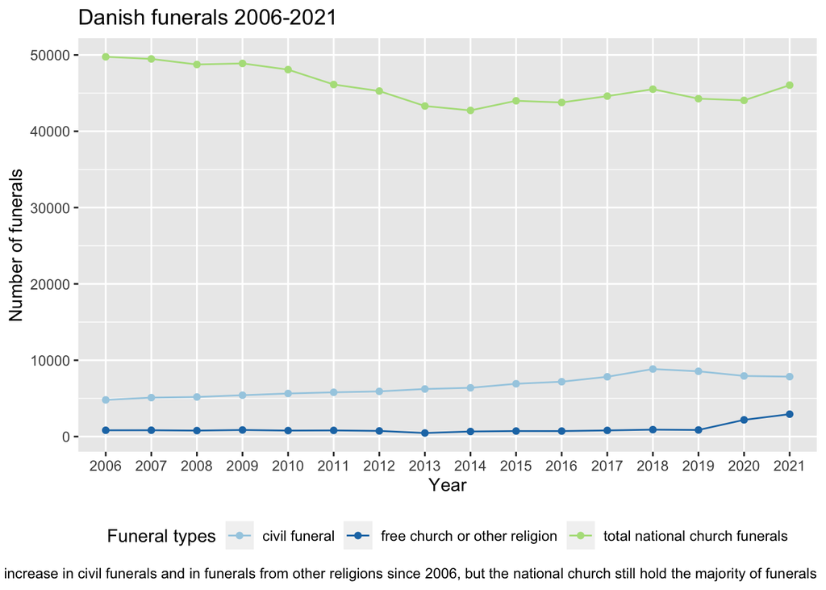

```r
funerals_plot <- ggplot(total_allfuneralstypes_long,aes(x=`year`, y=`number`, color=funeral_type, group=funeral_type)) +
  geom_line() +
  geom_point() +
  labs(title="Danish funerals 2006-2021",x="Year",y="Number of funerals", color="Funeral types",caption = "Figure 1: Small long term increase in civil funerals and in funerals from other religions since 2006, but the national church still hold the majority of funerals") +
  scale_color_brewer(palette = "Paired") + #choosing a color palette
  theme(legend.position="bottom") #moving the legend below the chart

funerals_plot # show chart
```

From the line chard I can see some trends:

*Long term trends:*

- small increase in the number of civil funerals and funerals held by other religions or free churches.
- Small decline in funerals in the national church.

*Short term trends:*

- small decline in civil funerals form 2018-2021. In the same period funerals in both the national church and in other religions or free churches are increasing.
- small increase in both civil funerals and funerals in national church from 2014-2018, which might just be due to a rise in the number of registered deaths.

Save the chart as PNG in fig_output repository:

```r
setwd('..') #set the current position

png(file="fig_output/funerals_linechart.png",
width=600, height=350)
funerals_plot
dev.off()
```

## Vizualisation 2 - comparing 2006 and 2021

For the next chart I want to know what percentage of the total funerals are civil funerals, funerals in the national church and funerals in other religions and free churches:

```r
#create sum row:
total_allfuneraltypes_sum <- total_allfuneraltypes %>%
  bind_rows(summarise_all(., ~if(is.numeric(.)) sum(.) else "total funerals"))

#calculating civil funerals percentage
civil_percent <- total_allfuneraltypes_sum[3,2:17]/total_allfuneraltypes_sum[4,2:17]*100
#calculating national church percentage
natchurch_percent <- total_allfuneraltypes_sum[2,2:17]/total_allfuneraltypes_sum[4,2:17]*100
#calculating other religions and free churches percentage
otherrel_freechurch_percent <- total_allfuneraltypes_sum[1,2:17]/total_allfuneraltypes_sum[4,2:17]*100
```

Creating three separate data frames with the percentage from above and a column containing the funeral type, and making the data frames into long format:

```r
#create data frame with percent and the funeral type
funeral_type = c("civil")
civil_percent_df <- cbind(funeral_type, civil_percent)
#Turn into long format
civil_percent_long <- civil_percent_df %>%
  gather(year, percent, -funeral_type)


#create data frame with percent and the funeral type
funeral_type = c("national church")
natchurch_percent_df <- cbind(funeral_type, natchurch_percent)
#Turn into long format
natchurch_percent_long <- natchurch_percent_df %>%
  gather(year, percent, -funeral_type)


#create data frame with percent and the funeral type
funeral_type = c("free church and other religions")
otherrel_percent_df <- cbind(funeral_type, otherrel_freechurch_percent)
#Turn into long format
otherrel_percent_long <- otherrel_percent_df %>%
  gather(year, percent, -funeral_type)
```

Combining the three data frames into one, which I can use for visualization:

```r
#Combine data frames

funerals_percent <- rbind(civil_percent_long,natchurch_percent_long, otherrel_percent_long)
```

Saving the data frame with the percentages of the different funeral types in a csv called `funerals_percent.csv`:

```r
setwd('..') #changing position
readr::write_csv(funerals_percent,"data_output/funerals_percent.csv")# creates a new csv
```

Creating a chard showing the percentage of the three different funeral types in 2006 and 2021:

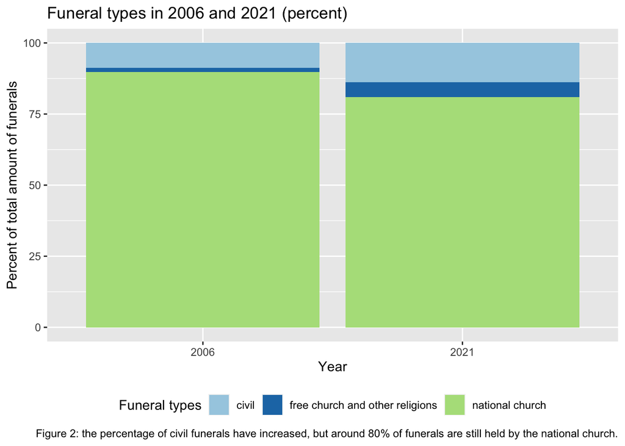

```r
percent_chart <- ggplot(funerals_percent[c(1,17,33,16,32,48),],aes(x=`year`, y=`percent`, fill=funeral_type)) + #the selected columns is the columns containing the years 2006 and 2021
  geom_bar(stat = "identity") +
   labs(title="Funeral types in 2006 and 2021 (percent)",x="Year",y="Percent of total amount of funerals", fill="Funeral types",caption = "Figure 2: the percentage of civil funerals have increased, but around 80% of funerals are still held by the national church.") + #editing names and captions
  scale_fill_brewer(type = "qual", palette = "Paired") + #choosing a color palette
  theme(legend.position="bottom") #moving the legend below the chart

percent_chart #show chart
```

Save the chart as PNG in fig_output repository:

```r
setwd('..') #set the current position

png(file="fig_output/percent_barchart.png",
width=600, height=350)
percent_chart
dev.off()
```

The comparison of 2006 and 2021 shows the following:

- The civil funerals have increased from 8,7% in 2006 to 13,8% in 2021.
- The funerals in free churches and other religions have increased from 1,5% in 2006 to 5.2% in 2021
- The funerals in the national church have decreased from 89,8% in 2006 to 81% in 2021.
- There are more civil funerals than funerals in free churches and other religions in both 2006 and 2021.

## Conclusion

From 2006-2021 there has been a small increase in civil funerals, but it is indeed very small. There has also been a small decline in funerals in the national church, but the national church still holds the great majority of funerals in Denmark.

There were a small decline in civil funerals from 2018-2021, and both funerals in national church and in other religions and free churches increased in the same period.